# ALY6010 - Module 3 R Practice

##### Name: Anubhav Saha

### Introduction

Hypothesis testing is the use of statistics to determine the probability that a given hypothesis is true. The usual process of hypothesis testing consists of four steps:

1. Formulate the null hypothesis H0 (commonly, that the observations are the result of pure chance) and the alternative hypothesis Ha (commonly, that the observations show a real effect combined with a component of chance variation).
2. Identify a test statistic that can be used to assess the truth of the null hypothesis.
3. Compute the P-value, which is the probability that a test statistic at least as significant as the one observed would be obtained assuming that the null hypothesis were true. The smaller the P-value, the stronger the evidence against the null hypothesis.
4. Compare the p-value to an acceptable significance value alpha (sometimes called an alpha value). If p<=alpha, that the observed effect is statistically significant, the null hypothesis is ruled out, and the alternative hypothesis is valid.

### Load the MASS, datasets and other required packages in R using the library function

```r
library(MASS) #Loading the package MASS
library(datasets)
library(dplyr)
library(ggpubr)
```

### One-sample t-test

Use the “chem” dataset to answer the question, “is the flour production company producing whole meal flour with greater than 1 part per million copper in it?”

#### code:

```r
chem #To glance our checm dataset
```

```
 [1]  2.90  3.10  3.40  3.40  3.70  3.70  2.80  2.50  2.40  2.40  2.70  2.20  5.28  3.37  3.03
[16]  3.03 28.95  3.77  3.40  2.20  3.50  3.60  3.70  3.70
```

```r
str(chem) #To get its structure
```

```
 num [1:24] 2.9 3.1 3.4 3.4 3.7 3.7 2.8 2.5 2.4 2.4 ...
```

```r
View(chem) #To view our dataset on a new window
MASS::chem #same as chem
```

```
 [1]  2.90  3.10  3.40  3.40  3.70  3.70  2.80  2.50  2.40  2.40  2.70  2.20  5.28  3.37  3.03
[16]  3.03 28.95  3.77  3.40  2.20  3.50  3.60  3.70  3.70
```

```r
?chem #To get help on our dataset
summary(chem) #Gives the five number summary of our dataset
```

```
   Min. 1st Qu.  Median    Mean 3rd Qu.    Max.
  2.200   2.775   3.385   4.280   3.700  28.950
```

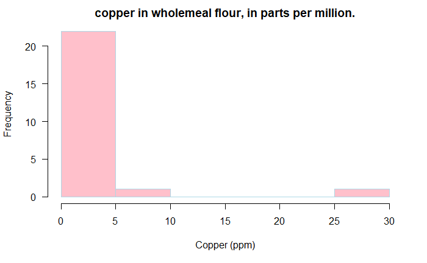

```r
hist(chem,
     main="copper in wholemeal flour, in parts per million.",
     xlab="Copper (ppm)",
     border="light blue",
     col="pink",
     las=1,
     breaks=5) #plots the histogram with given parameters
```

#### Step 1: Formulate Null and alternative Hypothesis

As we need to find out if there is > 1ppm of copper present, we’ll use a one tailed t test

Null hypothesis (H0) : The mean value of copper present is less than or equal to one, i.e. mu<=1

Alternative hypothesis (H1) : The mean value of copper present is greater than one, i.e. mu>1 (one tailed test)

#### Step 2: Identify the test statistic

Since n < 30, we will use the t statistic instead of the z statistic.

```r
?t.test
```

Performs one and two sample t-tests on vectors of data.

Default arguments: t.test(x, y = NULL, alternative = c(“two.sided”, “less”, “greater”), mu = 0, paired = FALSE, var.equal = FALSE, conf.level = 0.95, …)

#### Step 3: Compute the P-value

```r
ttest_chem <- t.test(chem,
                     alternative="greater",
                     mu = 1,
                     conf.level=0.99)
ttest_chem
```

```
    One Sample t-test

data:  chem
t = 3.0337, df = 23, p-value = 0.002952
alternative hypothesis: true mean is greater than 1
99 percent confidence interval:
 1.577245      Inf
sample estimates:
mean of x
 4.280417
```

```r
attributes(ttest_chem)
```

```
$names
 [1] "statistic"   "parameter"   "p.value"     "conf.int"    "estimate"    "null.value"
 [7] "stderr"      "alternative" "method"      "data.name"

$class
[1] "htest"
```

```r
ttest_chem$p.value
```

```
[1] 0.002951761
```

```r
ttest_chem$conf.int
```

```
[1] 1.577245      Inf
attr(,"conf.level")
[1] 0.99
```

#### Step 4: Compare the p-value to alpha

Since p-value < alpha (0.01), we can reject the NULL hypothesis and adopt our alternative hypothesis that mu > 1, i.e., the flour production company is producing whole meal flour with greater than 1 part per million copper in it.

### Two-sample t-test

Use the “cats” dataset to answer the question, “do male and female cat samples have the same body weight?”

#### code:

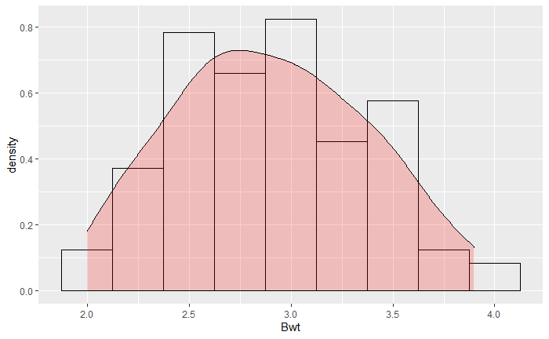

```r
?cats
View(cats)
male <- subset(cats, subset=(cats$Sex=="M")) # used subset function to get separate vectors for male and female cat body weight
female <- subset(cats, subset=(cats$Sex=="F"))

ggplot(male,aes(x=Bwt)) +
    geom_histogram(aes(y=..density..),binwidth=0.25,colour="black", fill="light grey") +
        geom_density(alpha=.2, fill="red")
```

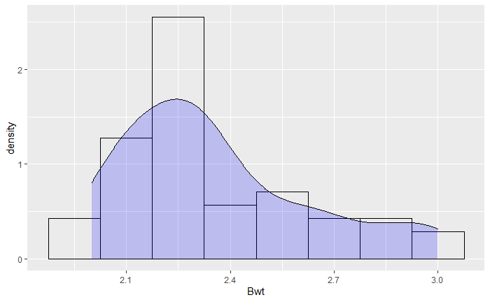

```r
ggplot(female,aes(x=Bwt)) +
    geom_histogram(aes(y=..density..),binwidth=0.15,colour="black", fill="light grey") +
        geom_density(alpha=.2, fill="blue")
```

```r
male_sample <- sample(male, size = 29, replace = TRUE) #Taking sample of 29 values so that n<30 to satisfy our t test constraints
female_sample <- sample(female, size = 29, replace = TRUE)
```

As we need to find out if the bwt of male cats and female cats are same or not, we’ll use a two tailed t test

Null hypothesis (H0) is as follows: Male and female cat samples have the same body weight, i.e difference of mean (mud) = 0

Alternative hypothesis (H1) is as follows: Male and female cat samples have unequal body weight, i.e difference of mean (mud) != 0

#### Two sample unpaired t test with unequal variances

```r
ttest_unpaired = t.test(male$Bwt, female$Bwt,
                        var.equal = FALSE,
                        paired=FALSE)
ttest_unpaired
```

```
    Welch Two Sample t-test

data:  male$Bwt and female$Bwt
t = 8.7095, df = 136.84, p-value = 8.831e-15
alternative hypothesis: true difference in means is not equal to 0
95 percent confidence interval:
 0.4177242 0.6631268
sample estimates:
mean of x mean of y
 2.900000  2.359574
```

**Intepretation of the results**

Since p-value < alpha (0.05), we can reject the NULL hypothesis and adopt our alternative hypothesis that mud!=0, i.e., male and female cats do not have same body weights.

### Paired t-test

Use the “shoes” dataset to answer the question, “did material A wear better than material B?”

#### code

```r
?shoes
shoes
```

```
$A
 [1] 13.2  8.2 10.9 14.3 10.7  6.6  9.5 10.8  8.8 13.3

$B
 [1] 14.0  8.8 11.2 14.2 11.8  6.4  9.8 11.3  9.3 13.6
```

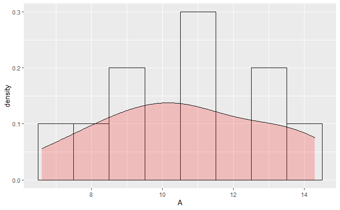

```r
shoe <- data.frame(shoes)
ggplot(shoe,aes(x=A)) +
    geom_histogram(aes(y=..density..),binwidth=1,colour="black", fill="light grey") +
        geom_density(alpha=.2, fill="red")
```

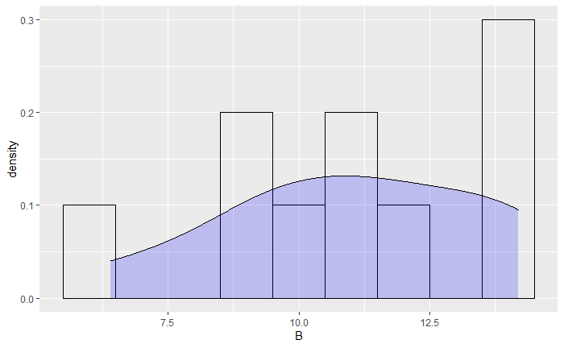

```r
ggplot(shoe,aes(x=B)) +
    geom_histogram(aes(y=..density..),binwidth=1,colour="black", fill="light grey") +
        geom_density(alpha=.2, fill="blue")
```

As we need to find out if the material A wears better than material B, we’ll use a one - tailed two sampled paired t test

Null hypothesis (H0) is as follows: Shoe of materal A wears worse or equal to the shoe of material B Alternative hypothesis (H1) is as follows: Shoe of materal A wears better than shoe of material B.

#### two sample paired t test

```r
paired = t.test(shoes$A, shoes$B,
                paired=TRUE,
                alternative="greater")
paired
```

```
    Paired t-test

data:  shoes$A and shoes$B
t = -3.3489, df = 9, p-value = 0.9957
alternative hypothesis: true difference in means is greater than 0
95 percent confidence interval:
 -0.6344264        Inf
sample estimates:
mean of the differences
                  -0.41
```

**Intepretation of the results**

Since p-value > alpha (0.05), we fail to reject the NULL hypothesis i.e.at 95% confidence level, there is not enough evidence to deny that Shoe of materal A wears worse or equal to the shoe of material B

### Independent two sample t-test

Link to the dataset lung capacity https://drive.google.com/file/d/0BxQfpNgXuWoIWUdZV1ZTc2ZscnM/edit?resourcekey=0-gqXT7Re2eUS2JGt_w1y4vA

```r
Data <- read.csv(file.choose())
View(Data)
```

```r
names(Data)
```

```
[1] "LungCap"   "Age"       "Height"    "Smoke"     "Gender"    "Caesarean"
```

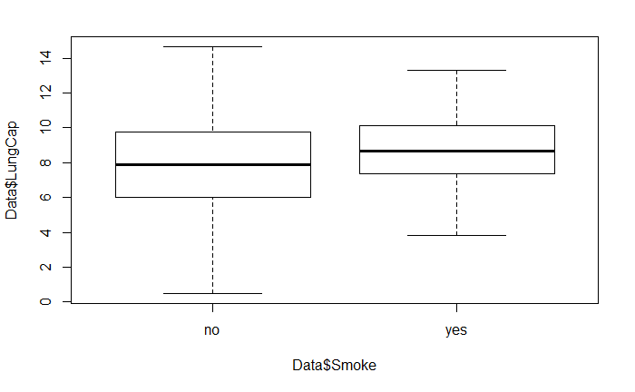

```r
boxplot(Data$LungCap ~ Data$Smoke)
```

Ho : Mean Lung capacity of smokers = that of non smokers i.e. difference in mean = 0 Ha : Mean Lung capacity of smokers != that of non smokers i.e. difference in mean != 0

Based on the boxplot, non smokers seem to have a higher variance.

Let’s confirm that by getting the variance

```r
var(Data$LungCap[Data$Smoke=="yes"])
```

```
[1] 3.545292
```

```r
var(Data$LungCap[Data$Smoke=="no"])
```

```
[1] 7.431694
```

#### Two sided t test

```r
t.test(Data$LungCap ~ Data$Smoke)
```

```
    Welch Two Sample t-test

data:  Data$LungCap by Data$Smoke
t = -3.6498, df = 117.72, p-value = 0.0003927
alternative hypothesis: true difference in means is not equal to 0
95 percent confidence interval:
 -1.3501778 -0.4003548
sample estimates:
 mean in group no mean in group yes
         7.770188          8.645455
```

If we wanna test for difference in mean more than 0, we can provide that argument during the t test